# Speed and Max bout length estimation : tuto

- Show All Code
- Hide All Code
- View Source

Author

Angelique Porciani

Published

Last Updated on 02 October, 2024

One of the parameters of interest is the duration of inactivity (or resting period). For estimate it, I need to compute the speed by timestep (mili or second) and apply a threshold to classify the larvae as moving or not. Here it is a detailled step of the analysis for individual tracked with rpi1 and for replicate 8. I apply all these step on all individual tracked in other script or at the end of this one.

# 1. Load previously NA cleaned data

```r
library(MoveR)
library(readr)
library(tidyverse)
library(zoo)

# 1.Filter NA : other script, application of NA filter (loss of tracking) Import data already cleaned -----
# Pb with this approach : separation by tracklet do not conserve frame order... loss of timline information.
rpi1_R08C<-data.table::fread(
  "../Data_larvae/data_larves_1hr/rpi1_10fps_R08_Corrected_cleanedData.csv.gz",
  sep = ";",
  dec = ".")

# selected individual for R08
ID_selected <- read.csv("../ID_selected_MoveR.csv")
ID_rpi108 <- ID_selected %>% filter(str_detect(fullID3, ".108"))
selIDrpi108 <- as.character(ID_rpi108$fullID3)

# Select only individual that are alive until LAM

rpi1_R08C_sub<- rpi1_R08C %>% filter(identity %in% selIDrpi108)

# Convert the data to a list of tracklets - here the data were saved as a varList object (a list of variable) a more simple structure than tracklets

trackDat_R08_sub_Cleaned <- MoveR::convert2Tracklets(rpi1_R08C_sub, by = "identity")

# set some useful information
trackDat_R08_sub_Cleaned <- MoveR::setInfo(trackDat_R08_sub_Cleaned, frameR = 10, scale = 1/37, imgRes = c(720, 1080))
```

Draw tracklets for the first 5 mins and selected individuals

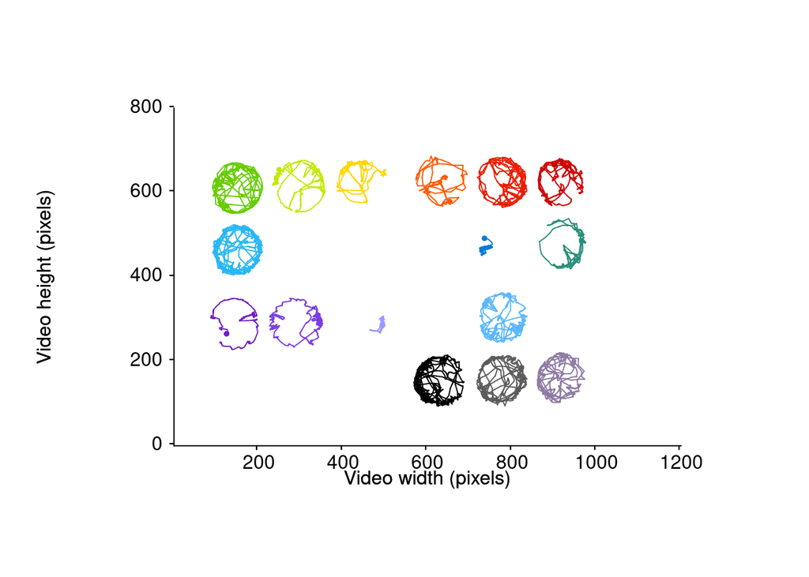

```r
# draw tracklet
MoveR::drawTracklets(trackDat_R08_sub_Cleaned,
                     imgRes = c(1080, 720),
                     #selId = selIDrpi108,
                     timeWin = list(c(0, 3000)),
                     #colGrad = viridis::viridis(10))
                     colId = "identity",
                     legend=F)
```

# 2. Speed estimation on 10 fps rate

And also mean speed (MA on 10 fps) and speed variance on 10 fps.

```r
trackDat_R08_sub_Cleaned <-
  MoveR::analyseTracklets(trackDat_R08_sub_Cleaned,
                          customFunc = list(
                            speed = function(x)
                              MoveR::speed(x,
                                           timeCol = "frame",
                                           scale = 1/37,# for in cm by second
                                           frameR=10,
                                           timeU="s"),
                            ### speed
                            slideMeanSpeed = function (y)
                              MoveR::slidWindow(y$speed,
                                                Tstep = 10,
                                                statistic = "mean",
                                                na.rm = T),
                            ### speed variance
                            slideVarSpeed = function (y)
                              MoveR::slidWindow(y$speed,
                                                Tstep = 10,
                                                statistic = "var",
                                                na.rm = T)
                          ))
```

Quick visualisation :

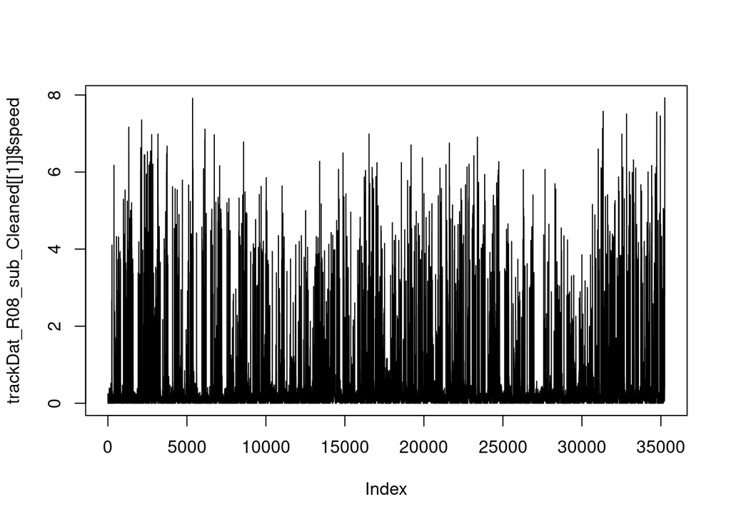

```r
plot(trackDat_R08_sub_Cleaned[[1]]$speed, type='l')
```

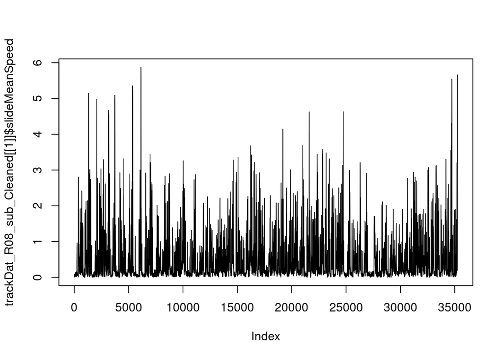

```r
plot(trackDat_R08_sub_Cleaned[[1]]$slideMeanSpeed, type='l')
```

# 3. Resampling by 1 second

```r
# 2.B. Resampling tracklet to 1 second
trackDat_R08_sub_Cleaned<-
  MoveR::analyseTracklets(trackDat_R08_sub_Cleaned,
                          customFunc = list(
                            # convert the time expressed in frame in second using a conversion factor of 25 frame per second
                            TimeSec = function(x)
                              x[["frame"]] / 10
                          ))

# resample the tracklets every 1 seconds
trackDat_R08_sub_Cleaned_byS <-
  MoveR::resampTracklets(trackDat_R08_sub_Cleaned, timeCol = "frame",  Tstep = 10)
```

Check size of time before and after sampling :

```r
## check the size of the tracklets
trackSize <- unlist(lapply(trackDat_R08_sub_Cleaned, function(x)
  nrow(x)))


## check the size of the tracklets after resampling
trackSize1s <- unlist(lapply(trackDat_R08_sub_Cleaned_byS, function(x)
  nrow(x)))

## Compare the tracklets size
cbind(trackSize, trackSize1s)
```

```
         trackSize trackSize1s
3108033      35250        3601
4108032      35468        3601
5108031      34650        3601
6108043      35664        3601
7108042      34106        3601
8108041      35970        3601
10108032     35846        3601
12108023     35008        3601
16108012     35053        3601
17108011     34631        3601
18108023     35831        3601
19108022     35987        3601
20108021     35872        3601
21108013     35948        3600
22108012     34948        3601
23108011     34854        3601
```

Draw trajectory by second

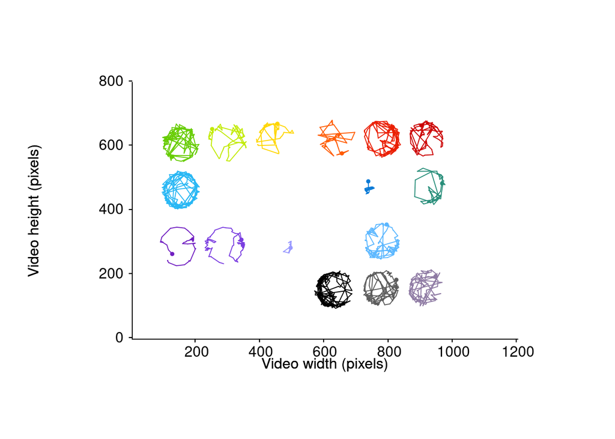

```r
MoveR::drawTracklets(trackDat_R08_sub_Cleaned_byS,
                     timeCol = "TimeSec",
                     imgRes = c(1080, 720),
                     #selId = selIDrpi108,
                     timeWin = list(c(0, 300)),
                     #colGrad = viridis::viridis(10))
                     colId = "identity",
                     legend=F)
```

Estimate activity

```r
trackDat_R08_sub_Cleaned_byS<-
  MoveR::analyseTracklets(trackDat_R08_sub_Cleaned_byS,
                          customFunc = list(
                            activity1 = function(x)
                            MoveR::activity1(x,
                                             speedCol = "speed",
                                             minSpeed = 0.3),
                            MaxSpeed=function(x) max(x[["speed"]], na.rm=TRUE)
                          ))

# seuil de 0.3 cm/s as in animalTA for now and corresponding to mean larval length
```

# 4. Extract max bout length for activ and inactif state

Traitement des NA => replacement par la précedente valeur (discutable mais c’est ce qu’il font dans ethoscopy) a garder pour les HMM surtout pour les TAngle

```r
#function of bout extraction
split_by_repetition <- function(vec) {
  if (sum(is.na(vec))>0){
    vec <- na.locf(vec)
  }
  if (sum(is.na(vec))==0){
    vec <- vec}
  # Identify the indices where consecutive numbers are broken or a repetition changes
  breaks <- c(0, which(diff(vec) != 0), length(vec))

  # Use those break points to split the vector into sublists
  result <- lapply(seq_along(breaks)[-length(breaks)], function(i) {
    vec[(breaks[i] + 1):breaks[i + 1]]
  })

  # now keep only ones corresponding to 1
  filtered_active <- Filter(function(x) all(x == 1), result)

  # same for 0
  filtered_inactive <- Filter(function(x) all(x == 0), result)

  res_Lb1<-max(unlist(lapply(filtered_active, length)))
  res_Lb_in<-max(unlist(lapply(filtered_inactive, length)))
  return(c(res_Lb1, res_Lb_in))
}

# apply
res_Lb<-list()
df_res <- data.frame(Max_bout_activ=NA, Max_bout_inactiv=NA, fullID3=NA)

for (i in 1:length(trackDat_R08_sub_Cleaned_byS)){
  res_Lb[[i]]<-split_by_repetition(trackDat_R08_sub_Cleaned_byS[[i]]$activity1)
  df_res[i,] <- data.frame(Max_bout_activ=res_Lb[[i]][1], Max_bout_inactiv=res_Lb[[i]][2], fullID3=names(trackDat_R08_sub_Cleaned_byS)[i])
}

library(kableExtra)
df_res %>% kbl(caption = "Estimation of max bout length for active and inactive for individuals of rpi1 R08",
               booktabs = T)%>%
    kable_styling(full_width = F)
```

Estimation of max bout length for active and inactive for individuals of rpi1 R08

| Max_bout_activ | Max_bout_inactiv | fullID3 |
| --- | --- | --- |
| 18 | 32 | 3108033 |
| 15 | 39 | 4108032 |
| 11 | 69 | 5108031 |
| 13 | 44 | 6108043 |
| 17 | 43 | 7108042 |
| 15 | 169 | 8108041 |
| 10 | 32 | 10108032 |
| 12 | 41 | 12108023 |
| 16 | 89 | 16108012 |
| 19 | 78 | 17108011 |
| 16 | 50 | 18108023 |
| 11 | 134 | 19108022 |
| 12 | 128 | 20108021 |
| 15 | 119 | 21108013 |
| 14 | 59 | 22108012 |
| 21 | 38 | 23108011 |

```r
str(df_res)
```

```
'data.frame':   16 obs. of  3 variables:
 $ Max_bout_activ  : int  18 15 11 13 17 15 10 12 16 19 ...
 $ Max_bout_inactiv: int  32 39 69 44 43 169 32 41 89 78 ...
 $ fullID3         : chr  "3108033" "4108032" "5108031" "6108043" ...
```